[figure not shown]

# **Analysis of COVID-19 data in United States**

## **Intorduction**

> Coronaviruses are a large family of viruses which may cause illness in animals or humans. In humans, several coronaviruses are known to cause respiratory infections ranging from the common cold to more severe diseases such as Middle East Respiratory Syndrome (MERS) and Severe Acute Respiratory Syndrome (SARS). The most recently discovered coronavirus causes coronavirus disease COVID-19. And now the number of cases of Coronavirus is soaring in the United States, and threaten our life.

> The World Health Organization suggests the best way to prevent and slow down transmission is to be well informed about the COVID-19 virus, the disease it causes and how it spreads. Protect yourself and others from infection by washing your hands or using an alcohol based rub frequently and not touching your face. ([*World Health Organization*](https://www.who.int/emergencies/diseases/novel-coronavirus-2019)).

> In this tutorial, we aim to tidy the COVID-19 data given from CDC, and analyze whether the World Health Organization prevention approach works by calculating the novel coronavirus growth rate over a particular time period. Each state may face different medical pressures in different months, so some patients with COVID-19 may not be tested in time. In this case, we will analyze the COVID-19 population detected in proportion to the total number of people tested to make the results more accurate. For readers unfamiliar with the coronavirus, we hope this analysis will give them a quick overview of what has happened in the US during this period. For readers who are aware of the new coronavirus, we hope they get some helpful information about the World Health Organization's approach to prevention in this tutorial.

#### *Begining draft*

> https://docs.google.com/document/d/11fQslM3EQ16nDm9S_ztp90IlAAfPOpdNPAY-WRJ8hHU/

#### *Related Data source*

1. CDC COVID Data Tracker: https://covid.cdc.gov/covid-data-tracker/
2. COVID-19 CORONAVIRUS PANDEMIC:  
   https://www.worldometers.info/coronavirus/
3. COVID-19 in USA: https://www.kaggle.com/sudalairajkumar/covid19-in-usa?select=us_states_covid19_daily.csv
4. CDC: How to Protect Yourself & Others: https://www.cdc.gov/coronavirus/2019-ncov/prevent-getting-sick/prevention.html
5. The face covering policy of Maryland started on April 18th https://governor.maryland.gov/wp-content/uploads/2020/04/Masks-and-Physical-Distancing-4.15.20.pdf
6. WHO protection: https://www.who.int/emergencies/diseases/novel-coronavirus-2019

#### *Related Graph source*

1. COVID-19 picture: https://www.fda.gov/food/food-safety-during-emergencies/food-safety-and-coronavirus-disease-2019-covid-19
2. Stay safe picture: https://www.trtworld.com/life/italy-again-sees-over-500-covid-19-deaths-in-one-day-latest-updates-41452

## **Data Collection**

### **1. Tools**

We used the following tools to collect this data: pandas, numpy, matplotlib, scikit-learn, seaborn, and more.

```python
import numpy as np
import pandas as pd
import matplotlib.pyplot as plt
import html5lib
import datetime
import seaborn as sns
from sklearn.linear_model import LinearRegression
import seaborn
import statsmodels.api as sm
from numpy import NaN
```

### **2. Data scraping**

To determine the growth trend COVID-19 in U.S.A, we are first going to take a look at the case of COVID-19 in U.S.A daily. We are going to scrape this data from [CDC](https://covid.cdc.gov/covid-data-tracker/) and kaggle. Because the browner didn't provide the visual form, so we downloaded the data as csv, and upload the csv into the project instead grab the website url in our project

```python
# upload us_covid19_daily.csv
from google.colab import files
uploaded1 = files.upload()
```

Upload widget is only available when the cell has been executed in the current browser session. Please rerun this cell to enable.

```
Saving us_covid19_daily.csv to us_covid19_daily.csv
```

Below we will take you through the data for eleven months (2020-1-22 to 2020-12-06) in U.S.A, so there will be enough data help you understand the growth of Covid-19 case over time.

```python
# process the covid19 daily csv
import pandas as pd
import io

daily_table = pd.read_csv(io.BytesIO(uploaded1['us_covid19_daily.csv']))
daily_table
```

|  | date | states | positive | negative | pending | hospitalizedCurrently | hospitalizedCumulative | inIcuCurrently | inIcuCumulative | onVentilatorCurrently | onVentilatorCumulative | recovered | dateChecked | death | hospitalized | totalTestResults | lastModified | total | posNeg | deathIncrease | hospitalizedIncrease | negativeIncrease | positiveIncrease | totalTestResultsIncrease | hash |
| --- | --- | --- | --- | --- | --- | --- | --- | --- | --- | --- | --- | --- | --- | --- | --- | --- | --- | --- | --- | --- | --- | --- | --- | --- | --- |
| 0 | 20201206 | 56 | 14534035 | 161986294 | 13592.0 | 101487.0 | 585676.0 | 20145.0 | 31946.0 | 7094.0 | 3322.0 | 5624444.0 | 2020-12-06T24:00:00Z | 273374.0 | 585676.0 | 204063869 | 2020-12-06T24:00:00Z | 0 | 0 | 1138 | 2256 | 1172590 | 176771 | 1634532 | 9cf16504f91958e803a2197daf8c2528a4eddc18 |
| 1 | 20201205 | 56 | 14357264 | 160813704 | 13433.0 | 101190.0 | 583420.0 | 19950.0 | 31831.0 | 7005.0 | 3321.0 | 5576026.0 | 2020-12-05T24:00:00Z | 272236.0 | 583420.0 | 202429337 | 2020-12-05T24:00:00Z | 0 | 0 | 2445 | 3316 | 1526995 | 211073 | 2169756 | 6249216c5f097c94ce33a811dab011a483a42404 |
| 2 | 20201204 | 56 | 14146191 | 159286709 | 12714.0 | 101276.0 | 580104.0 | 19858.0 | 31608.0 | 6999.0 | 3305.0 | 5470389.0 | 2020-12-04T24:00:00Z | 269791.0 | 580104.0 | 200259581 | 2020-12-04T24:00:00Z | 0 | 0 | 2563 | 4652 | 1260657 | 224831 | 1854869 | ae30ea088584335ba4d57ee927f8dbda6add74db |
| 3 | 20201203 | 56 | 13921360 | 158026052 | 15106.0 | 100755.0 | 575452.0 | 19723.0 | 31276.0 | 6867.0 | 3280.0 | 5404018.0 | 2020-12-03T24:00:00Z | 267228.0 | 575452.0 | 198404712 | 2020-12-03T24:00:00Z | 0 | 0 | 2706 | 5331 | 1238465 | 210204 | 1828230 | 0f253d185ecb336cdd18a4c61996eda1b7eef13b |
| 4 | 20201202 | 56 | 13711156 | 156787587 | 14368.0 | 100322.0 | 570121.0 | 19680.0 | 31038.0 | 6855.0 | 3252.0 | 5322128.0 | 2020-12-02T24:00:00Z | 264522.0 | 570121.0 | 196576482 | 2020-12-02T24:00:00Z | 0 | 0 | 2733 | 5028 | 982032 | 195796 | 1459202 | 477c17b6302d0485195e77ecf8270a974f7a3c82 |
| ... | ... | ... | ... | ... | ... | ... | ... | ... | ... | ... | ... | ... | ... | ... | ... | ... | ... | ... | ... | ... | ... | ... | ... | ... | ... |
| 315 | 20200126 | 2 | 0 | 0 | NaN | NaN | NaN | NaN | NaN | NaN | NaN | NaN | 2020-01-26T24:00:00Z | NaN | NaN | 2 | 2020-01-26T24:00:00Z | 0 | 0 | 0 | 0 | 0 | 0 | 0 | 69c67c81e64d10a5270497fc5336779c06fb812b |
| 316 | 20200125 | 2 | 0 | 0 | NaN | NaN | NaN | NaN | NaN | NaN | NaN | NaN | 2020-01-25T24:00:00Z | NaN | NaN | 2 | 2020-01-25T24:00:00Z | 0 | 0 | 0 | 0 | 0 | 0 | 0 | 9ea5731f5b0a79617b994d6842eecfdbeb1dde35 |
| 317 | 20200124 | 2 | 0 | 0 | NaN | NaN | NaN | NaN | NaN | NaN | NaN | NaN | 2020-01-24T24:00:00Z | NaN | NaN | 2 | 2020-01-24T24:00:00Z | 0 | 0 | 0 | 0 | 0 | 0 | 0 | 287531342bc8d5f2650b0cc12ebcca3807a64b7b |
| 318 | 20200123 | 2 | 0 | 0 | NaN | NaN | NaN | NaN | NaN | NaN | NaN | NaN | 2020-01-23T24:00:00Z | NaN | NaN | 2 | 2020-01-23T24:00:00Z | 0 | 0 | 0 | 0 | 0 | 0 | 1 | e0563aac8e1bc7b8b8059c52831b97179ff6f981 |
| 319 | 20200122 | 2 | 0 | 0 | NaN | NaN | NaN | NaN | NaN | NaN | NaN | NaN | 2020-01-22T24:00:00Z | NaN | NaN | 1 | 2020-01-22T24:00:00Z | 0 | 0 | 0 | 0 | 0 | 0 | 0 | e0caa1c66c4aa83baf227afe12261a1493fc0d7e |

320 rows × 25 columns

In the above Operators dataset, there are 25 columns. We have:

1. Date
2. State number
3. positive
4. negative
5. pending
6. hospitalizedCurrently

   .....

Which there are a lot of data we will not gonna to use. Also there are 320 rows which is a lot. In next step we are going to tidy the data.

### **3. Data processing**

Since we are only going to analyze the number of COVID-19 cases, the number of deaths, the number of cures and the number of tests, the first step we want do is to drop the column we are not going to use. Also, I noticed in date column, the date is only represented by 6 digital number, which may look confuse. So I decided convert it to datetime object. Moreover, I extract the month from date, for next step.

```python
# tidy the data from above
daily = daily_table.copy()

# drop the useless data
daily.drop(['hash','lastModified','total','posNeg','hospitalized','hospitalizedIncrease','pending','hospitalizedCurrently','hospitalizedCumulative',
            'inIcuCurrently','inIcuCumulative','onVentilatorCurrently','onVentilatorCumulative','dateChecked'], axis = 1, inplace = True)

# transform date to datetime object and extract the month
daily['month'] = daily['date'].astype(str).str[4:6]
daily['date'] = daily['date'].astype(str).str[0:4] + '-' + daily['date'].astype(str).str[4:6]+ '-'+ daily['date'].astype(str).str[6:8]
daily
```

|  | date | states | positive | negative | recovered | death | totalTestResults | deathIncrease | negativeIncrease | positiveIncrease | totalTestResultsIncrease | month |
| --- | --- | --- | --- | --- | --- | --- | --- | --- | --- | --- | --- | --- |
| 0 | 2020-12-06 | 56 | 14534035 | 161986294 | 5624444.0 | 273374.0 | 204063869 | 1138 | 1172590 | 176771 | 1634532 | 12 |
| 1 | 2020-12-05 | 56 | 14357264 | 160813704 | 5576026.0 | 272236.0 | 202429337 | 2445 | 1526995 | 211073 | 2169756 | 12 |
| 2 | 2020-12-04 | 56 | 14146191 | 159286709 | 5470389.0 | 269791.0 | 200259581 | 2563 | 1260657 | 224831 | 1854869 | 12 |
| 3 | 2020-12-03 | 56 | 13921360 | 158026052 | 5404018.0 | 267228.0 | 198404712 | 2706 | 1238465 | 210204 | 1828230 | 12 |
| 4 | 2020-12-02 | 56 | 13711156 | 156787587 | 5322128.0 | 264522.0 | 196576482 | 2733 | 982032 | 195796 | 1459202 | 12 |
| ... | ... | ... | ... | ... | ... | ... | ... | ... | ... | ... | ... | ... |
| 315 | 2020-01-26 | 2 | 0 | 0 | NaN | NaN | 2 | 0 | 0 | 0 | 0 | 01 |
| 316 | 2020-01-25 | 2 | 0 | 0 | NaN | NaN | 2 | 0 | 0 | 0 | 0 | 01 |
| 317 | 2020-01-24 | 2 | 0 | 0 | NaN | NaN | 2 | 0 | 0 | 0 | 0 | 01 |
| 318 | 2020-01-23 | 2 | 0 | 0 | NaN | NaN | 2 | 0 | 0 | 0 | 1 | 01 |
| 319 | 2020-01-22 | 2 | 0 | 0 | NaN | NaN | 1 | 0 | 0 | 0 | 0 | 01 |

320 rows × 12 columns

Now we have below information:

1. Date
2. State number
3. total positive case
4. total negative case
5. total recovered case
6. their growth rate each day

   .....

Since this form is recording the data for each day from 2020-1-22 to 2020-12-6. So it will be so crowded if I draw all those data on my graph. So in this step, I decided to summarized the data for each month. I am going to extract the row for the last day in each month to represent the data on that month, and I calculated the difference between each row to shows the growth rate in each month

```python
# Since the there a too much data, I am gonna analyize the summarized data in each month

# get the data from the last day in each month
row1 = daily.loc[daily['date'].astype(str).str.contains('30')].copy()
row2 = daily.loc[daily['date'].astype(str).str.contains('12-06')].copy()
row3 = daily.loc[daily['date'].astype(str).str.contains('2-28')].copy()
row = row1.append(row2)
row = row.append(row3)
row = row.sort_values('month', ascending = True)

# calculate the new increase rate for each factor
row['positiveIncrease'] = row.positive.diff()
row['deathIncrease'] = row.death.diff()
row['negativeIncrease'] = row.negative.diff()
row['totalTestResultsIncrease'] = row.totalTestResults.diff()
row['recoveredIncrease'] = row.recovered.diff()
row
```

|  | date | states | positive | negative | recovered | death | totalTestResults | deathIncrease | negativeIncrease | positiveIncrease | totalTestResultsIncrease | month | recoveredIncrease |
| --- | --- | --- | --- | --- | --- | --- | --- | --- | --- | --- | --- | --- | --- |
| 311 | 2020-01-30 | 3 | 0 | 0 | NaN | NaN | 5 | NaN | NaN | NaN | NaN | 01 | NaN |
| 282 | 2020-02-28 | 7 | 0 | 0 | NaN | 4.0 | 6490 | NaN | 0.0 | 0.0 | 6485.0 | 02 | NaN |
| 251 | 2020-03-30 | 56 | 172740 | 818231 | 4560.0 | 3425.0 | 1035705 | 3421.0 | 818231.0 | 172740.0 | 1029215.0 | 03 | NaN |
| 220 | 2020-04-30 | 56 | 1073745 | 5263080 | 154587.0 | 59599.0 | 6543127 | 56174.0 | 4444849.0 | 901005.0 | 5507422.0 | 04 | 150027.0 |
| 190 | 2020-05-30 | 56 | 1769819 | 14941329 | 494308.0 | 99865.0 | 17312676 | 40266.0 | 9678249.0 | 696074.0 | 10769549.0 | 05 | 339721.0 |
| 159 | 2020-06-30 | 56 | 2623989 | 29829805 | 813219.0 | 120087.0 | 33841528 | 20222.0 | 14888476.0 | 854170.0 | 16528852.0 | 06 | 318911.0 |
| 129 | 2020-07-30 | 56 | 4454538 | 50311353 | 1413102.0 | 144053.0 | 58102601 | 23966.0 | 20481548.0 | 1830549.0 | 24261073.0 | 07 | 599883.0 |
| 98 | 2020-08-30 | 56 | 5943743 | 71109595 | 2152344.0 | 175274.0 | 83299643 | 31221.0 | 20798242.0 | 1489205.0 | 25197042.0 | 08 | 739242.0 |
| 67 | 2020-09-30 | 56 | 7165483 | 92959838 | 2838664.0 | 198993.0 | 110928031 | 23719.0 | 21850243.0 | 1221740.0 | 27628388.0 | 09 | 686320.0 |
| 37 | 2020-10-30 | 56 | 8958126 | 119043563 | 3576201.0 | 221496.0 | 144951353 | 22503.0 | 26083725.0 | 1792643.0 | 34023322.0 | 10 | 737537.0 |
| 6 | 2020-11-30 | 56 | 13338607 | 153863841 | 5146643.0 | 259316.0 | 192776284 | 37820.0 | 34820278.0 | 4380481.0 | 47824931.0 | 11 | 1570442.0 |
| 0 | 2020-12-06 | 56 | 14534035 | 161986294 | 5624444.0 | 273374.0 | 204063869 | 14058.0 | 8122453.0 | 1195428.0 | 11287585.0 | 12 | 477801.0 |

## **Data visualization Analysis**

### **1. Overall Data**

Below graph I am going to draw the increase trend of total positive case,total death case, and total recovered case over month from the 'positive', 'death', 'recovered' column. And then merge the graph to help compare them, and figure what's going on.

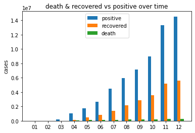

```python
# Draw graph to compare total positive case, total death case, and total recovered case over month
labels = row['month']
x = np.arange(len(labels))  # the label locations
width = 0.25  # the width of the bars

fig, ax = plt.subplots()
rects1 = ax.bar(x-0.25, row['positive'], width, label='positive')
rects2 = ax.bar(x, row['recovered'], width, label='recovered')
rects3 = ax.bar(x+0.25, row['death'], width, label='death')

# Add some text for labels, title and custom x-axis tick labels, etc.
ax.set_ylabel('cases')
ax.set_title('death & recovered vs positive over time')
ax.set_xticks(x)
ax.set_xticklabels(labels)
ax.legend()
```

According to the graph above, we found an exponential increase in the number of people with the Covid-19, it means the Covid-19 growth rate in U.S.A becomes ever more rapid in proportion to the growing total number or size.

There is also an exponential increase in the number of people that recovered from Covid-19. This is good news because it shows there will be people with COVID-19 will be curedit more rapid. However, the growth rate of recovered population seems still less than the growth rath of COVID-19 population. It means the current state of health care in the country is insufficient to stop the growth of the COVID-19 population.

The numbers of death only linear growthed over times, even the Covid-19 population is expontial increase. this is a good news, actually this means the death rate over all population are going to decrease.

Now we know the increase trend for total population of COVID-19 & total death population & total recovered population, and I analyze that the population with Covid-19 and recovered population growth rate are increase over time, but the growth rate for death population are constant So in next step I am going to draw the growth rate for population of COVID-19 & death population & recovered population to confirm my analyze.

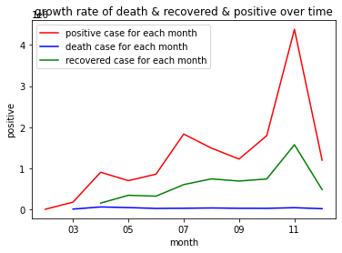

```python
# Draw graph compare the growth rate of positive case & death case & recovered case over month
ax = row.plot('month', 'positiveIncrease', kind='line', c='r', label='positive case for each month')
row.plot('month', 'deathIncrease', kind='line', c='b', ax = ax, label='death case for each month')
row.plot('month', 'recoveredIncrease', kind='line', c='g', ax = ax, label='recovered case for each month')

# Add some text for labels, title and custom x-axis tick labels, etc.
plt.title('growth rate of death & recovered & positive over time')
plt.xlabel('month')
plt.ylabel('positive')
```

In first graph, I assume the growth rate of Total positive case is greater than the growth rate for total recovered, and the growth rate is close to constant, so for this one I am going to make a linear regression and scatter plot to confirm my analyize

```
regression for positive case is :
2.25e+05 x + 6.958e+05
regression for death is :
-2858 x + 4.143e+04
regression for recovered is :
9.878e+04 x + 2.293e+05
```

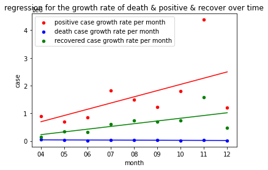

```python
# drop NaN element
drop_NaN = row[3:]

# calculate the regresssion for positive
x_axis = range(0, len(drop_NaN['positiveIncrease'].tolist()))
y_axis = drop_NaN['positiveIncrease'].tolist()

reg = np.polyfit(x = x_axis, y = y_axis, deg = 1)
ry = np.poly1d(reg)
yvals_positive = ry (x_axis)
print("regression for positive case is :", ry)

# calculate the regresssion for death
x_axis = range(0, len(drop_NaN['deathIncrease'].tolist()))
y_axis = drop_NaN['deathIncrease'].tolist()

reg = np.polyfit(x = x_axis, y = y_axis, deg = 1)
ry = np.poly1d(reg)
yvals_death = ry (x_axis)
print("regression for death is :", ry)

# calculate the regresssion for recovered
x_axis = range(0, len(drop_NaN['recoveredIncrease'].tolist()))
y_axis = drop_NaN['recoveredIncrease'].tolist()
reg = np.polyfit(x = x_axis, y = y_axis, deg = 1)
ry = np.poly1d(reg)
yvals_recovered = ry (x_axis)
print("regression for recovered is :", ry)

# drow scatter plot
ax = drop_NaN.plot('month', 'positiveIncrease', kind='scatter', c='r', label='positive case growth rate per month')
drop_NaN.plot('month', 'deathIncrease', kind='scatter', c='b', ax = ax, label='death case growth rate per month')
drop_NaN.plot('month', 'recoveredIncrease', kind='scatter', c='g', ax = ax, label='recovered case growth rate per month')

# drow linear regression
ax.plot(drop_NaN['month'], yvals_positive,color='red')
ax.plot(drop_NaN['month'], yvals_death,color='blue')
ax.plot(drop_NaN['month'], yvals_recovered,color='green')

# title, label, etc.
plt.title('regression for the growth rate of death & positive & recover over time')
plt.xlabel('month')
plt.ylabel('case')
plt.show()
```

### **2. special period**

#### *What is the impact of Thanksgiving in the epidemic?*

According to the graph above, we indicated there is a gap between Oct and Nov. We assume that this is caused by Thanksgiving period (many people are going outside, some of them even not wearing mask, which is violance to the [World Health Organization](https://www.who.int/emergencies/diseases/novel-coronavirus-2019) and [CDC](https://www.cdc.gov/coronavirus/2019-ncov/prevent-getting-sick/prevention.html) instruction.

According to cdc, the symptom usually starts on the 5th day. Considering the time it needs for the testing, I would use 14 days as a period. Since Thanksgiving is Nov 26th, i would consider data before the 25th and after 24th. I choose 25th instead of 26th because people usually travel back home a day before Thanksgiving. Since traveling increases the risk of getting infection, there is a higher chance that the virus will spread to the whole family through the family members who travel back home. The data for the second period after the 24th should have a dramatic increase compared with the previous period.

```python
#table before thx giving
daily['date'] = pd.to_datetime(daily['date'])
daily.sort_values(by=['date'], inplace=True)
thx_af = daily.loc[daily['date'] >= datetime.datetime(2020,11,25)]
thx_af = thx_af.loc[daily['date'] <= datetime.datetime(2020,11,25)+datetime.timedelta(days=14)]

#table after thx giving
thx_bf = daily.loc[daily['date'] < datetime.datetime(2020,11,25)]
thx_bf = thx_bf.loc[daily['date'] >= (datetime.datetime(2020,11,25)-datetime.timedelta(days=14))]
```

```
regression after thanks giving is :
1.787e+05 x + 1.251e+07
```

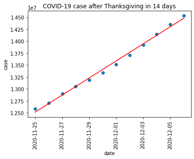

```python
#plot the data after Thanksgiving
x_axis = np.arange(0, len(thx_af['positive'].tolist()))
y_axis = thx_af['positive'].tolist()

reg = np.polyfit(x = x_axis, y = y_axis, deg = 1)
ry = np.poly1d(reg)
yvals_af = ry (x_axis)
print("regression after thanks giving is :", ry)

plt.title("COVID-19 case after Thanksgiving in 14 days")
plt.xlabel("date")
plt.ylabel("case")
plt.xticks(rotation = 'vertical')
plt.scatter(thx_af['date'], y_axis)
plt.plot(thx_af['date'],yvals_af,color='red')
```

```
regression before thanks giving is :
1.647e+05 x + 1.025e+07
```

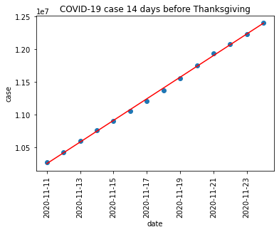

```python
#plot the data before regression date
x_axis = range(0, len(thx_bf['positive'].tolist()))
y_axis = thx_bf['positive'].tolist()

reg = np.polyfit(x = x_axis, y = y_axis, deg = 1)
ry = np.poly1d(reg)
yvals_bf = ry (x_axis)
print("regression before thanks giving is :", ry)

plt.title("COVID-19 case 14 days before Thanksgiving")
plt.xlabel("date")
plt.ylabel("case")
plt.xticks(rotation = 'vertical')
plt.scatter(thx_bf['date'], y_axis)
plt.plot(thx_bf['date'],yvals_bf,color='red')
```

#### *Data support Epidemic gets worse during Thanksgiving :(*

According to above graph, we indicated that there is a great gap between Oct and Nov. We assume this is caused by Thanksgiving day (in that period there are many people crowded in mall, and some of them may even not wearing mask, which is violenced to the WHO insturction)

In order to show the evidence that the epidemic gets worse during Thanksgiving, we need to take a look at the plot of both before period and after period. On the before period graph, the regression line shows the slope is 1.647e+05. Then, we compare the slope of the after period, which is 1.787e+05. In the after period, the slope has increased 0.14e+05. This means the increase of positive cases in the after period is faster than the previous period.

This result same to what we hypothesis, crowded people + not wearing mask will cause more cases of COVID-19.

## **Each State Daily Data Collection**

### **1. Data scraping**

To determine the growth trend COVID-19 in each states in U.S.A we are first going to take a look at the case of COVID-19 in us_states_covid19_daily. We are going to scrape this data from [CDC](https://covid.cdc.gov/covid-data-tracker/) and [kaggle](https://www.kaggle.com/sudalairajkumar/covid19-in-usa?select=us_states_covid19_daily.csv). Because the browner didn't provide the visual form, so we downloaded the data as csv, and upload the csv into the project instead grab the website url in our project

```python
# upload state COVID-19 information
from google.colab import files
uploaded2 = files.upload()
```

Upload widget is only available when the cell has been executed in the current browser session. Please rerun this cell to enable.

```
Saving us_states_covid19_daily.csv to us_states_covid19_daily.csv
```

Below we will take you through the data for eleven months (2020-1-22 to 2020-12-06) in each state, so there will be enough data help you understand the growth of Covid-19 in each state over time.

```python
# process the STATES covid19 daily csv
import pandas as pd
import io

state_table = pd.read_csv(io.BytesIO(uploaded2['us_states_covid19_daily.csv']))
state_table.head()
```

|  | date | state | positive | probableCases | negative | pending | totalTestResultsSource | totalTestResults | hospitalizedCurrently | hospitalizedCumulative | inIcuCurrently | inIcuCumulative | onVentilatorCurrently | onVentilatorCumulative | recovered | dataQualityGrade | lastUpdateEt | dateModified | checkTimeEt | death | hospitalized | dateChecked | totalTestsViral | positiveTestsViral | negativeTestsViral | positiveCasesViral | deathConfirmed | deathProbable | totalTestEncountersViral | … |
| --- | --- | --- | --- | --- | --- | --- | --- | --- | --- | --- | --- | --- | --- | --- | --- | --- | --- | --- | --- | --- | --- | --- | --- | --- | --- | --- | --- | --- | --- | --- |
| 0 | 20201206 | AK | 35720.0 | NaN | 1042056.0 | NaN | totalTestsViral | 1077776.0 | 164.0 | 799.0 | NaN | NaN | 21.0 | NaN | 7165.0 | A | 12/6/2020 03:59 | 2020-12-06T03:59:00Z | 12/05 22:59 | 143.0 | 799.0 | 2020-12-06T03:59:00Z | 1077776.0 | 43746.0 | 1032815.0 | NaN | 143.0 | NaN | NaN | … |
| 1 | 20201206 | AL | 269877.0 | 45962.0 | 1421126.0 | NaN | totalTestsPeopleViral | 1645041.0 | 1927.0 | 26331.0 | NaN | 2290.0 | NaN | 1317.0 | 168387.0 | A | 12/6/2020 11:00 | 2020-12-06T11:00:00Z | 12/06 06:00 | 3889.0 | 26331.0 | 2020-12-06T11:00:00Z | NaN | NaN | NaN | 223915.0 | 3462.0 | 427.0 | NaN | … |
| 2 | 20201206 | AR | 170924.0 | 22753.0 | 1614979.0 | NaN | totalTestsViral | 1763150.0 | 1076.0 | 9401.0 | 374.0 | NaN | 179.0 | 1038.0 | 149490.0 | A+ | 12/6/2020 00:00 | 2020-12-06T00:00:00Z | 12/05 19:00 | 2660.0 | 9401.0 | 2020-12-06T00:00:00Z | 1763150.0 | NaN | 1614979.0 | 148171.0 | 2437.0 | 223.0 | NaN | … |
| 3 | 20201206 | AS | 0.0 | NaN | 2140.0 | NaN | totalTestsViral | 2140.0 | NaN | NaN | NaN | NaN | NaN | NaN | NaN | D | 12/1/2020 00:00 | 2020-12-01T00:00:00Z | 11/30 19:00 | 0.0 | NaN | 2020-12-01T00:00:00Z | 2140.0 | NaN | NaN | 0.0 | NaN | NaN | NaN | … |
| 4 | 20201206 | AZ | 364276.0 | 12590.0 | 2018813.0 | NaN | totalTestsPeopleViral | 2370499.0 | 2977.0 | 28248.0 | 714.0 | NaN | 462.0 | NaN | 56382.0 | A+ | 12/6/2020 00:00 | 2020-12-06T00:00:00Z | 12/05 19:00 | 6950.0 | 28248.0 | 2020-12-06T00:00:00Z | NaN | NaN | NaN | 351686.0 | 6431.0 | 519.0 | NaN | … |

In the above Operators dataset, there are 55 columns. We have:

1. Date
2. State name
3. positive
4. probableCases
5. negative
6. pending

   .....

Which there are a lot of data we will not gonna to use. Also there are 15633 rows which is a lot. In next step we are going to tidy the data.

```python
# tidy the data
state = state_table.copy()

# drop useless column
state.drop(['hash','commercialScore','probableCases','negativeRegularScore','pending', 'hospitalizedCurrently','hospitalizedCumulative',
            'onVentilatorCumulative','lastUpdateEt','dateModified','checkTimeEt','dateChecked','deathConfirmed','deathProbable','totalTestsViral',
            'negativeTestsViral','positiveCasesViral','deathConfirmed','deathProbable','totalTestEncountersViral','totalTestsPeopleViral',
            'negativeTestsAntibody','totalTestsPeopleAntibody','positiveTestsPeopleAntibody','negativeTestsPeopleAntibody','totalTestsPeopleAntigen',
            'totalTestsAntigen','positiveTestsAntigen','fips','totalTestResultsSource','posNeg','negativeScore','positiveScore','totalTestsAntibody',
            'positiveTestsAntibody','inIcuCurrently','inIcuCumulative','onVentilatorCurrently','positiveTestsViral','positiveTestsPeopleAntigen',
            'total','hospitalized','hospitalizedIncrease', 'dataQualityGrade','score', 'grade'], axis = 1, inplace = True)

#extract month and change date to datetime object
state['month'] = state['date'].astype(str).str[4:6]
state['date'] = state['date'].astype(str).str[0:4] + '-' + state['date'].astype(str).str[4:6]+ '-'+ state['date'].astype(str).str[6:8]
state['date'] = pd.to_datetime(state['date'])
state
```

|  | date | state | positive | negative | totalTestResults | recovered | death | positiveIncrease | negativeIncrease | totalTestResultsIncrease | deathIncrease | month |
| --- | --- | --- | --- | --- | --- | --- | --- | --- | --- | --- | --- | --- |
| 0 | 2020-12-06 | AK | 35720.0 | 1042056.0 | 1077776.0 | 7165.0 | 143.0 | 757 | 9788 | 10545 | 0 | 12 |
| 1 | 2020-12-06 | AL | 269877.0 | 1421126.0 | 1645041.0 | 168387.0 | 3889.0 | 2288 | 5769 | 7880 | 12 | 12 |
| 2 | 2020-12-06 | AR | 170924.0 | 1614979.0 | 1763150.0 | 149490.0 | 2660.0 | 1542 | 13244 | 14704 | 40 | 12 |
| 3 | 2020-12-06 | AS | 0.0 | 2140.0 | 2140.0 | NaN | 0.0 | 0 | 0 | 0 | 0 | 12 |
| 4 | 2020-12-06 | AZ | 364276.0 | 2018813.0 | 2370499.0 | 56382.0 | 6950.0 | 5376 | 15661 | 20586 | 25 | 12 |
| ... | ... | ... | ... | ... | ... | ... | ... | ... | ... | ... | ... | ... |
| 15628 | 2020-01-24 | WA | 0.0 | 0.0 | 0.0 | NaN | NaN | 0 | 0 | 0 | 0 | 01 |
| 15629 | 2020-01-23 | MA | NaN | NaN | 2.0 | NaN | NaN | 0 | 0 | 1 | 0 | 01 |
| 15630 | 2020-01-23 | WA | 0.0 | 0.0 | 0.0 | NaN | NaN | 0 | 0 | 0 | 0 | 01 |
| 15631 | 2020-01-22 | MA | NaN | NaN | 1.0 | NaN | NaN | 0 | 0 | 0 | 0 | 01 |
| 15632 | 2020-01-22 | WA | 0.0 | 0.0 | 0.0 | NaN | NaN | 0 | 0 | 0 | 0 | 01 |

15633 rows × 12 columns

Now we have below information:

1. Date
2. State name
3. total positive case
4. total negative case
5. total recovered case
6. their growth rate each day

   .....

```python
# because the data there is too big, so I will only use the data from the last day on each month
row1 = state.loc[state['date'].astype(str).str.contains('30')].copy()
row2 = state.loc[state['date'].astype(str).str.contains('12-06')].copy()
row3 = state.loc[state['date'].astype(str).str.contains('2-28')].copy()
row = row1.append(row2)
row = row.append(row3)
row = row.sort_values('month', ascending = True)

# calculate the new increase rate
row['positiveIncrease'] = row.positive.diff()
row['deathIncrease'] = row.death.diff()
row['negativeIncrease'] = row.negative.diff()
row['totalTestResultsIncrease'] = row.totalTestResults.diff()
row
```

|  | date | state | positive | negative | totalTestResults | recovered | death | positiveIncrease | negativeIncrease | totalTestResultsIncrease | deathIncrease | month |
| --- | --- | --- | --- | --- | --- | --- | --- | --- | --- | --- | --- | --- |
| 15615 | 2020-01-30 | WA | 0.0 | 0.0 | 0.0 | NaN | NaN | NaN | NaN | NaN | NaN | 01 |
| 15614 | 2020-01-30 | MA | NaN | NaN | 4.0 | NaN | NaN | NaN | NaN | 4.0 | NaN | 01 |
| 15613 | 2020-01-30 | FL | 0.0 | NaN | 1.0 | NaN | NaN | NaN | NaN | -3.0 | NaN | 01 |
| 15495 | 2020-02-28 | WA | 0.0 | 0.0 | 0.0 | NaN | 4.0 | 0.0 | NaN | -1.0 | NaN | 02 |
| 15493 | 2020-02-28 | NJ | NaN | NaN | 0.0 | NaN | 0.0 | NaN | NaN | 0.0 | -4.0 | 02 |
| ... | ... | ... | ... | ... | ... | ... | ... | ... | ... | ... | ... | ... |
| 26 | 2020-12-06 | MO | 322298.0 | 1544226.0 | 3196185.0 | NaN | 4192.0 | -28564.0 | -756909.0 | -1235492.0 | 208.0 | 12 |
| 28 | 2020-12-06 | MS | 164931.0 | 982395.0 | 1147326.0 | 128746.0 | 3961.0 | -157367.0 | -561831.0 | -2048859.0 | -231.0 | 12 |
| 29 | 2020-12-06 | MT | 67875.0 | 620339.0 | 688214.0 | 50287.0 | 736.0 | -97056.0 | -362056.0 | -459112.0 | -3225.0 | 12 |
| 14 | 2020-12-06 | IA | 213390.0 | 885199.0 | 1098589.0 | 159063.0 | 2683.0 | 145515.0 | 264860.0 | 410375.0 | 1947.0 | 12 |
| 20 | 2020-12-06 | LA | 251123.0 | 3356960.0 | 3608083.0 | 202891.0 | 6584.0 | 37733.0 | 2471761.0 | 2509494.0 | 3901.0 | 12 |

570 rows × 12 columns

### **2. Data visualization**

We want to explore the total positive case & total death & total recovered case changes over each month in each states, to see whether there are special case happened. So I made a stacked bar graph grab the data from 'month','positive','death','recovered' in state table

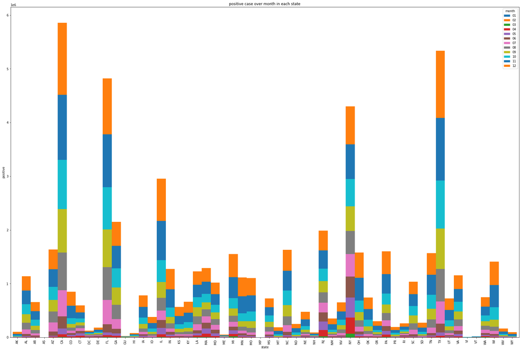

```python
# compare each state's positive case in each month
plot_case = row.pivot(index='state', columns='month', values='positive')
plot_case.plot.bar(stacked = True, figsize = (30, 20), fontsize = 10, width = 1 , xlabel = ("state"), ylabel = ('positive'),
                   title = ('positive case over month in each state'))
```

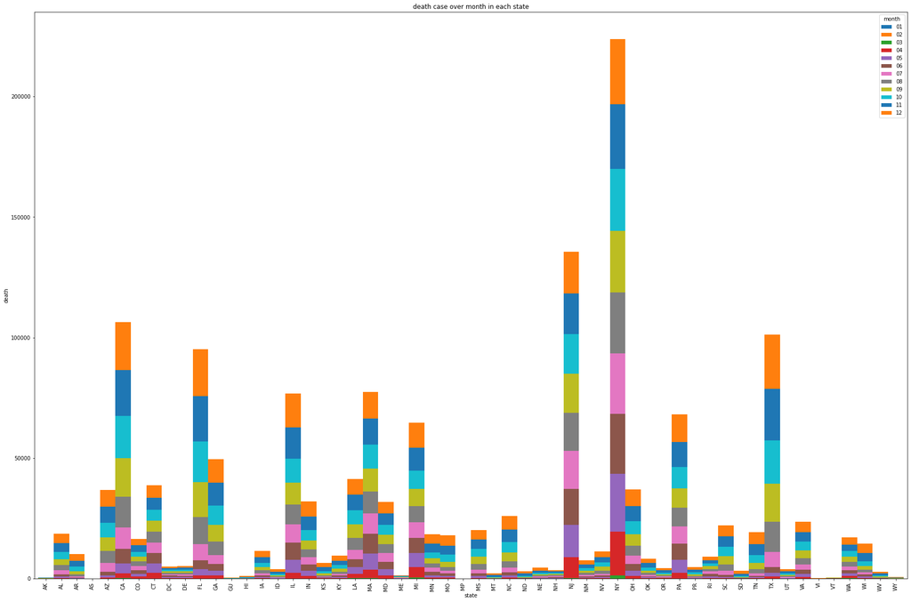

```python
# compare each state's death case in each month
plot_case = row.pivot(index='state', columns='month', values='death')
plot_case.plot.bar(stacked = True, figsize = (30, 20), fontsize = 10, width = 1 , xlabel = ("state"), ylabel = ('death'),
                   title = ('death case over month in each state'))
```

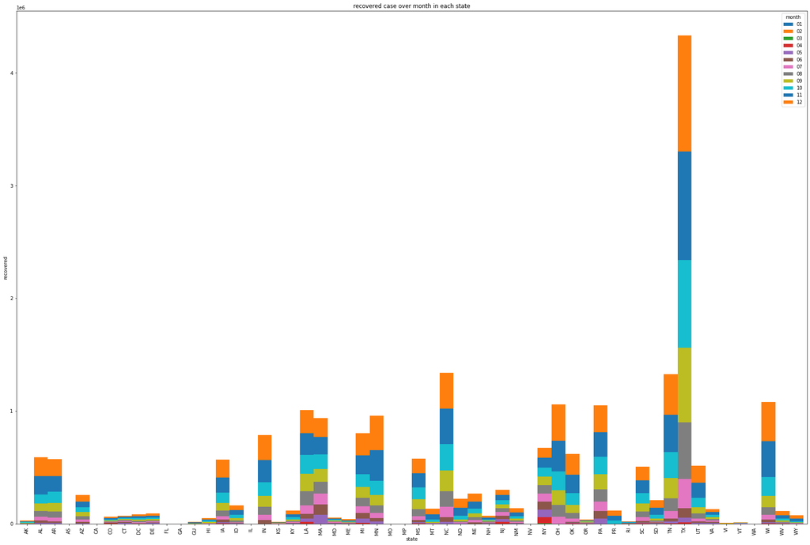

```python
# compare each state's recovered case in each month
plot_case = row.pivot(index='state', columns='month', values='recovered')
plot_case.plot.bar(stacked = True, figsize = (30, 20), fontsize = 10, width = 1 , xlabel = ("state"), ylabel = ('recovered'),
                   title = ('recovered case over month in each state'))
```

This shows that the TX have highest total recovered case

## **3. Analyize for speical map (MD)**

We found some interest thing in above graph, so now we are going to extract some speical state and see what's happening there

Because I am currently in MD, I was wondering how COVID-19 growth in MD. So I extract all MD information from the Us state daily table by loc the row in state column that contaion 'MD'

```python
# extract the MD information only from the above dataframe
MDcase = state.loc[state['state'].astype(str).str.contains('MD')].copy()
MDcase
```

|  | date | state | positive | negative | totalTestResults | recovered | death | positiveIncrease | negativeIncrease | totalTestResultsIncrease | deathIncrease | month |
| --- | --- | --- | --- | --- | --- | --- | --- | --- | --- | --- | --- | --- |
| 22 | 2020-12-06 | MD | 215027.0 | 2225595.0 | 4685476.0 | 8785.0 | 4846.0 | 2643 | 14799 | 48348 | 26 | 12 |
| 78 | 2020-12-05 | MD | 212384.0 | 2210796.0 | 4637128.0 | 8780.0 | 4820.0 | 3193 | 16700 | 53900 | 30 | 12 |
| 134 | 2020-12-04 | MD | 209191.0 | 2194096.0 | 4583228.0 | 8751.0 | 4790.0 | 3792 | 16154 | 55912 | 26 | 12 |
| 190 | 2020-12-03 | MD | 205399.0 | 2177942.0 | 4527316.0 | 8675.0 | 4764.0 | 2044 | 9939 | 31305 | 49 | 12 |
| 246 | 2020-12-02 | MD | 203355.0 | 2168003.0 | 4496011.0 | 8648.0 | 4715.0 | 2220 | 11427 | 35566 | 42 | 12 |
| ... | ... | ... | ... | ... | ... | ... | ... | ... | ... | ... | ... | ... |
| 15222 | 2020-03-09 | MD | 5.0 | 73.0 | NaN | NaN | NaN | 2 | 21 | 0 | 0 | 03 |
| 15273 | 2020-03-08 | MD | 3.0 | 52.0 | NaN | NaN | NaN | 0 | 11 | 0 | 0 | 03 |
| 15324 | 2020-03-07 | MD | 3.0 | 41.0 | NaN | NaN | NaN | 0 | 15 | 0 | 0 | 03 |
| 15371 | 2020-03-06 | MD | 3.0 | 26.0 | NaN | NaN | NaN | 3 | 9 | 0 | 0 | 03 |
| 15404 | 2020-03-05 | MD | 0.0 | 17.0 | NaN | NaN | NaN | 0 | 0 | 0 | 0 | 03 |

277 rows × 12 columns

Now we have below information:

1. Date
2. State-MD
3. total positive case in MD
4. total negative case in MD
5. total recovered case in MD
6. their growth rate each day

.....

```python
# the information of COVID-19 each month in MD
row1 = MDcase.loc[MDcase['date'].astype(str).str.contains('30')].copy()
row2 = MDcase.loc[MDcase['date'].astype(str).str.contains('2-28')].copy()
row = row1.append(row2)

row = row.sort_values('month', ascending = True)
row['positiveIncrease'] = row.positive.diff()
row['deathIncrease'] = row.death.diff()
row['negativeIncrease'] = row.negative.diff()
row['totalTestResultsIncrease'] = row.totalTestResults.diff()
row['recoveredIncrease'] = row.recovered.diff()
row
```

|  | date | state | positive | negative | totalTestResults | recovered | death | positiveIncrease | negativeIncrease | totalTestResultsIncrease | deathIncrease | month | recoveredIncrease |
| --- | --- | --- | --- | --- | --- | --- | --- | --- | --- | --- | --- | --- | --- |
| 14078 | 2020-03-30 | MD | 1413.0 | 13316.0 | 13204.0 | NaN | 35.0 | NaN | NaN | NaN | NaN | 03 | NaN |
| 12342 | 2020-04-30 | MD | 21742.0 | 92617.0 | 118325.0 | 1432.0 | 1226.0 | 20329.0 | 79301.0 | 105121.0 | 1191.0 | 04 | NaN |
| 10662 | 2020-05-30 | MD | 52015.0 | 241931.0 | 333724.0 | 3649.0 | 2562.0 | 30273.0 | 149314.0 | 215399.0 | 1336.0 | 05 | 2217.0 |
| 8926 | 2020-06-30 | MD | 67559.0 | 468296.0 | 647019.0 | 4982.0 | 3190.0 | 15544.0 | 226365.0 | 313295.0 | 628.0 | 06 | 1333.0 |
| 7246 | 2020-07-30 | MD | 87177.0 | 806788.0 | 1180591.0 | 5592.0 | 3488.0 | 19618.0 | 338492.0 | 533572.0 | 298.0 | 07 | 610.0 |
| 5510 | 2020-08-30 | MD | 107791.0 | 1211447.0 | 1919515.0 | 6124.0 | 3752.0 | 20614.0 | 404659.0 | 738924.0 | 264.0 | 08 | 532.0 |
| 3774 | 2020-09-30 | MD | 124725.0 | 1493282.0 | 2605913.0 | 7536.0 | 3949.0 | 16934.0 | 281835.0 | 686398.0 | 197.0 | 09 | 1412.0 |
| 2094 | 2020-10-30 | MD | 144314.0 | 1782204.0 | 3389678.0 | 8164.0 | 4137.0 | 19589.0 | 288922.0 | 783765.0 | 188.0 | 10 | 628.0 |
| 358 | 2020-11-30 | MD | 198370.0 | 2146539.0 | 4429749.0 | 8608.0 | 4641.0 | 54056.0 | 364335.0 | 1040071.0 | 504.0 | 11 | 444.0 |

We assume that the growth rate of positive case growth rate would decrease after the April, because people are following the the [World Health Organization](https://www.who.int/emergencies/diseases/novel-coronavirus-2019) and [CDC](https://www.cdc.gov/coronavirus/2019-ncov/prevent-getting-sick/prevention.html) instruction.. To confirm my hypothesis that the protection and increase of COVID-19 case are related, we decide first draw a over all graph analyize how death ratio & recovered ratio & positive case ratio changing in each month. and see whether it increased after April. We can do this by making a stacked bar plot using plt.bar.

[figure not shown]

```python
# compare the death ratio & recovered ratio & positive ratio over month in maryland
labels = row['month']
x = np.arange(len(labels))  # the label locations
width = 0.25  # the width of the bars

fig, ax = plt.subplots(figsize=(10, 25))
rects1 = ax.bar(x, row['positiveIncrease'], width, label='positiveIncrease')
rects2 = ax.bar(x, row['recoveredIncrease'], width, label='recoveredIncrease')
rects3 = ax.bar(x, row['deathIncrease'], width, label='deathIncrease')


# Add some text for labels, title and custom x-axis tick labels, etc.
ax.set_ylabel('increase ratio')
ax.set_title('death ratio & recovered ratio vs positive ratio over time')
ax.set_xticks(x)
ax.set_xticklabels(labels)
ax.legend()

# add mean value of each factor to help analyize
ax.axhline(row["positiveIncrease"].mean(), color="pink", linewidth=2, label='mean COVID-19 increase rate')
ax.axhline(row["deathIncrease"].mean(), color="purple", linewidth=2, label='mean death rate')
ax.axhline(row["recoveredIncrease"].mean(), color="red", linewidth=2, label='mean recovered rate')
```

The over all graph seems not support my hypothesis that in May the growth rate of positive case are Significantly higher than the growth rate from April. So in below, I would like to confirm that by drawing linear regression of total positive case before & after 14 days from masking policy.

### **Does wearing a mask protect people from Covid-19?**

Although some of the countries in the world have asked citizens to wear mask in public in order to prevent the spread of virus, U.S. has difficulty to ask their citizens to follow the order to wear mask. One of the reasons that U.S. citizens refuse to wear the mask is they doubt the effect of wearing a mask. In this section, Maryland will be analysed to determine whether wearing masks prevent the spread of virus and prevent the person who wears the mask or not.

In this section the data will be determine with a period of 14 days. The Maryland Governor released the execution order document to ask the citizens in Maryland to wear mask started on April 18th 7:00. Since 7:00 is the time people usually start their day usually, the data needs to analyse is 14 days before 18th and 14 days after the 17th. The data of before mask order and after mask order will be compared.

```python
#The face covering policy of Maryland started on April 18th

# table before 18th
MDcase.sort_values(by=['date'], inplace=True)
mask_af = MDcase.loc[MDcase['date'] >= datetime.datetime(2020,4,18)]
mask_af = mask_af.loc[MDcase['date'] < (datetime.datetime(2020,4,18)+datetime.timedelta(days=14))]

#table after 18th(include 18th)
mask_bf = MDcase.loc[MDcase['date'] < datetime.datetime(2020,4,18)]
mask_bf = mask_bf.loc[MDcase['date'] >= (datetime.datetime(2020,4,18)-datetime.timedelta(days=14))]
```

```
regression before Governor's order is :
664.2 x + 2865
```

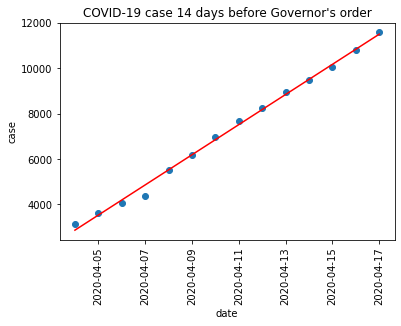

```python
# regression plot before the mask order.

x_axis = range(0, len(mask_bf['positive'].tolist()))
y_axis = mask_bf['positive'].tolist()

reg = np.polyfit(x = x_axis, y = y_axis, deg = 1)
ry = np.poly1d(reg)
yvals_bf = ry (x_axis)
print("regression before Governor's order is :", ry)

plt.title("COVID-19 case 14 days before Governor's order")
plt.xlabel("date")
plt.ylabel("case")
plt.xticks(rotation = 'vertical')
plt.scatter(mask_bf['date'], y_axis)
plt.plot(mask_bf['date'],yvals_bf,color='red')
```

```
regression after Governor's order is :
840.3 x + 1.183e+04
```

[figure not shown]

```python
# regression plot after the mask order.

x_axis = range(0, len(mask_af['positive'].tolist()))
y_axis = mask_af['positive'].tolist()

reg = np.polyfit(x = x_axis, y = y_axis, deg = 1)
ry = np.poly1d(reg)
yvals_bf = ry (x_axis)
print("regression after Governor's order is :", ry)

plt.title("COVID-19 case 14 days after Govenor's order(includ 18th)")
plt.xlabel("date")
plt.ylabel("case")
plt.xticks(rotation = 'vertical')
plt.scatter(mask_af['date'], y_axis)
plt.plot(mask_af['date'],yvals_bf,color='red')
```

### **Wearing mask might not be able to protect you from Covid-19**

By comparing the regression slope value of both before period and after period, it seems the slope value has increased after the mask order. The value increased from 664.2 to 840.3. This means the slope rate has increased almost a quarter of itself. But it is too early to say the mask is not effective.

In the next section, we will take a deeper look at the data by comparing the testing positive rate and the daily testing number to help us to answer the question.

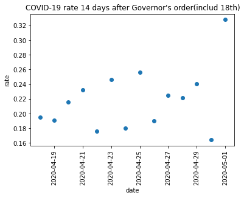

```python
# positive rate after mask order

idx = 0
rate_lst = []
while idx <= 13:
  rate = mask_af['positiveIncrease'].iloc[idx] / mask_af['totalTestResultsIncrease'].iloc[idx]
  rate_lst.append(rate)
  idx = idx+1

plt.title("COVID-19 rate 14 days after Governor's order(includ 18th)")
plt.xlabel("date")
plt.ylabel("rate")
plt.xticks(rotation = 'vertical')
plt.scatter(mask_af['date'], rate_lst)
```

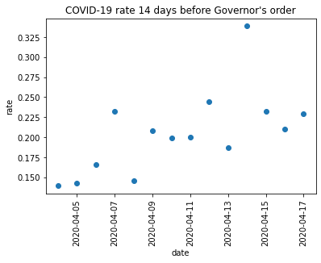

```python
# positive rate before mask order

idx = 0
rate_lst = []
while idx <= 13:
  rate = mask_bf['positiveIncrease'].iloc[idx] / mask_bf['totalTestResultsIncrease'].iloc[idx]
  rate_lst.append(rate)
  idx = idx+1

plt.title("COVID-19 rate 14 days before Governor's order")
plt.xlabel("date")
plt.ylabel("rate")
plt.xticks(rotation = 'vertical')
plt.scatter(mask_bf['date'], rate_lst)
```

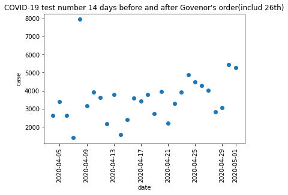

```python
# daily test number 14 days before and after mask order

daily_test = pd.concat([mask_bf, mask_af])
idx = 0
daily_lst = []

while idx < 28:
  daily_lst.append(daily_test['totalTestResultsIncrease'].iloc[idx])
  idx = idx+1

plt.title("COVID-19 test number 14 days before and after Govenor's order(includ 26th)")
plt.xlabel("date")
plt.ylabel("case")
x_axis = daily_test['date']
plt.xticks(rotation = 'vertical')
plt.scatter(x_axis, daily_lst)
```

### **It is still unclear to answer the question**

In both plot of the before and after period, after, there is no obvious trend to predict the rate of next date. It might not change dramatically, it might have a huge increase or decrease. Both plots are not very helpful to answer the question. Both of the plots have an outlier that is extremely higher than the rest of the data.

In the after period plot, it seems there is a potential trend. If the rate value decreases, then the rate value of the next day will increase except April 20th.

The daily test value doesn't seem to be helpful to us as well. There is an outlier that is extremely larger than the rest of the data. Although it seems the value increased globally speaking, the relationship between daily numbers has no obvious relationship.

There are several reasons that we may need to consider. First, even the order started on the 18th, that does not mean people will strictly follow the order. The second reason is labs were having difficulty to run the test due the large amount of the sample come in. It is possible that they will test the sample from the other day due to the sample amount exceed its maximum amount of performing test.

In order to find out more evidence to help us to answer the question, we may need to look at some of the other countries that strictly follow the mask order when it is published.

## **3. Analyize for speical map (MN)**

According to one of the graph, the MN have related high COVID-19 population, andmeanwhile, I found the George Floyd protests are an ongoing series of police brutality protests that began in Minneapolis in the United States on May 26, 2020. I this two things may related, since during protection, many people are going outside without wearing mask, which is violance to the [World Health Organization](https://www.who.int/emergencies/diseases/novel-coronavirus-2019) and [CDC](https://www.cdc.gov/coronavirus/2019-ncov/prevent-getting-sick/prevention.html) instruction. I am going to extract all MN information from the Us state daily table by loc the row in state column that contaion 'MN'

```python
# extrace MN COVID-19 information from the state dataframe
MNcase = state.loc[state['state'].astype(str).str.contains('MN')].copy()
MNcase
```

|  | date | state | positive | negative | totalTestResults | recovered | death | positiveIncrease | negativeIncrease | totalTestResultsIncrease | deathIncrease | month |
| --- | --- | --- | --- | --- | --- | --- | --- | --- | --- | --- | --- | --- |
| 25 | 2020-12-06 | MN | 350862.0 | 2301135.0 | 4431677.0 | 308218.0 | 3984.0 | 5581 | 19757 | 61042 | 64 | 12 |
| 81 | 2020-12-05 | MN | 345281.0 | 2281378.0 | 4370635.0 | 301081.0 | 3920.0 | 6308 | 12161 | 48295 | 75 | 12 |
| 137 | 2020-12-04 | MN | 338973.0 | 2269217.0 | 4322340.0 | 293151.0 | 3845.0 | 5347 | 18469 | 55360 | 61 | 12 |
| 193 | 2020-12-03 | MN | 333626.0 | 2250748.0 | 4266980.0 | 290019.0 | 3784.0 | 6149 | 14306 | 48363 | 92 | 12 |
| 249 | 2020-12-02 | MN | 327477.0 | 2236442.0 | 4218617.0 | 286219.0 | 3692.0 | 5165 | 12827 | 38689 | 77 | 12 |
| ... | ... | ... | ... | ... | ... | ... | ... | ... | ... | ... | ... | ... |
| 15174 | 2020-03-10 | MN | 11.0 | 132.0 | 143.0 | NaN | NaN | 6 | 52 | 58 | 0 | 03 |
| 15225 | 2020-03-09 | MN | 5.0 | 80.0 | 85.0 | NaN | NaN | 3 | 32 | 35 | 0 | 03 |
| 15276 | 2020-03-08 | MN | 2.0 | 48.0 | 50.0 | NaN | NaN | 0 | 0 | 0 | 0 | 03 |
| 15327 | 2020-03-07 | MN | 2.0 | 48.0 | 50.0 | NaN | NaN | 1 | 12 | 13 | 0 | 03 |
| 15373 | 2020-03-06 | MN | 1.0 | 36.0 | 37.0 | NaN | NaN | 0 | 0 | 0 | 0 | 03 |

276 rows × 12 columns

Now we have below information:

1. Date
2. State-MN
3. total positive case in MN
4. total negative case in MN
5. total recovered case in MN
6. their growth rate each day

.....

```python
# the information of COVID-19 each month in MN
row1 = MNcase.loc[MNcase['date'].astype(str).str.contains('30')].copy()
row2 = MNcase.loc[MNcase['date'].astype(str).str.contains('2-28')].copy()
row = row1.append(row2)
row = row.sort_values('month', ascending = True)
row['positiveIncrease'] = row.positive.diff()
row['deathIncrease'] = row.death.diff()
row['negativeIncrease'] = row.negative.diff()
row['totalTestResultsIncrease'] = row.totalTestResults.diff()
row['recoveredIncrease'] = row.recovered.diff()
row
```

|  | date | state | positive | negative | totalTestResults | recovered | death | positiveIncrease | negativeIncrease | totalTestResultsIncrease | deathIncrease | month | recoveredIncrease |
| --- | --- | --- | --- | --- | --- | --- | --- | --- | --- | --- | --- | --- | --- |
| 14081 | 2020-03-30 | MN | 823.0 | 19512.0 | 20335.0 | NaN | 10.0 | NaN | NaN | NaN | NaN | 03 | NaN |
| 12345 | 2020-04-30 | MN | 8116.0 | 73349.0 | 81465.0 | 1829.0 | 343.0 | 7293.0 | 53837.0 | 61130.0 | 333.0 | 04 | NaN |
| 10665 | 2020-05-30 | MN | 26181.0 | 250392.0 | 276573.0 | 17864.0 | 1036.0 | 18065.0 | 177043.0 | 195108.0 | 693.0 | 05 | 16035.0 |
| 8929 | 2020-06-30 | MN | 36303.0 | 569013.0 | 605316.0 | 31601.0 | 1476.0 | 10122.0 | 318621.0 | 328743.0 | 440.0 | 06 | 13737.0 |
| 7249 | 2020-07-30 | MN | 53692.0 | 954190.0 | 1007882.0 | 46965.0 | 1634.0 | 17389.0 | 385177.0 | 402566.0 | 158.0 | 07 | 15364.0 |
| 5513 | 2020-08-30 | MN | 75189.0 | 1046882.0 | 1478432.0 | 66916.0 | 1865.0 | 21497.0 | 92692.0 | 470550.0 | 231.0 | 08 | 19951.0 |
| 3777 | 2020-09-30 | MN | 99134.0 | 1315567.0 | 2030167.0 | 89392.0 | 2089.0 | 23945.0 | 268685.0 | 551735.0 | 224.0 | 09 | 22476.0 |
| 2097 | 2020-10-30 | MN | 145465.0 | 1691334.0 | 2774695.0 | 125052.0 | 2437.0 | 46331.0 | 375767.0 | 744528.0 | 348.0 | 10 | 35660.0 |
| 361 | 2020-11-30 | MN | 318763.0 | 2217580.0 | 4156622.0 | 272608.0 | 3593.0 | 173298.0 | 526246.0 | 1381927.0 | 1156.0 | 11 | 147556.0 |
| 25 | 2020-12-06 | MN | 350862.0 | 2301135.0 | 4431677.0 | 308218.0 | 3984.0 | 32099.0 | 83555.0 | 275055.0 | 391.0 | 12 | 35610.0 |

To confirm my hypothesis that the protection and increase of COVID-19 case are related, we decide first draw a over all graph analyize how death ratio & recovered ratio & positive case ratio changing in each month. and see whether it increased after May. We can do this by making a stacked bar plot using plt.bar.

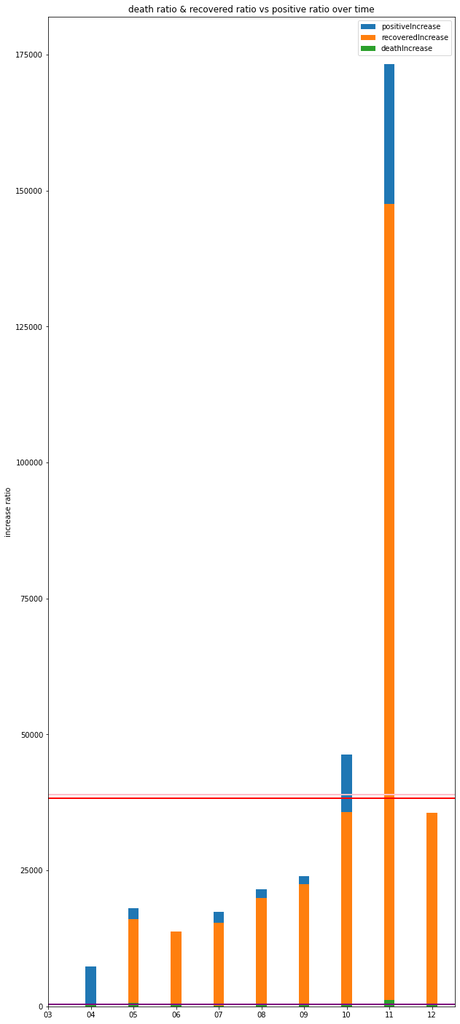

```python
# draw compare graph for death ratio & positive ratio & recovered ratio
labels = row['month']
x = np.arange(len(labels))  # the label locations
width = 0.25  # the width of the bars

fig, ax = plt.subplots(figsize=(10, 25))
rects1 = ax.bar(x, row['positiveIncrease'], width, label='positiveIncrease')
rects2 = ax.bar(x, row['recoveredIncrease'], width, label='recoveredIncrease')
rects3 = ax.bar(x, row['deathIncrease'], width, label='deathIncrease')


# Add some text for labels, title and custom x-axis tick labels, etc.
ax.set_ylabel('increase ratio')
ax.set_title('death ratio & recovered ratio vs positive ratio over time')
ax.set_xticks(x)
ax.set_xticklabels(labels)
ax.legend()

# add mean value for each factor to help analyize
ax.axhline(row["positiveIncrease"].mean(), color="pink", linewidth=2, label='mean COVID-19 increase rate')
ax.axhline(row["deathIncrease"].mean(), color="purple", linewidth=2, label='mean death rate')
ax.axhline(row["recoveredIncrease"].mean(), color="red", linewidth=2, label='mean recovered rate')
```

### **What is the impact of the protest in epidemic?**

On May 25th, Mr. George Floyd was murdered in Minneapolis, Minnesota. The people of the U.S. will not tolerate it anymore. People started walking to the street to protest and speak their voices. A lot of footage from the live broadcast showed protesters didn't wear masks.

In this section, the data of Minnesota will be analyzed to determine the impact of protest in the epidemic. The protest started on May 26th. Therefore, we will analyze the data 14 days before 26th and 14 days after the 25th. In this section a period is 14 days.

```python
#The George Floyd protest started on May 26th

#table before May 26th
MNcase.sort_values(by=['date'], inplace=True)
floyd_af = MNcase.loc[MNcase['date'] >= datetime.datetime(2020,5,26)]
floyd_af = floyd_af.loc[MNcase['date'] < (datetime.datetime(2020,5,26)+datetime.timedelta(days=14))]

#table after May 26th(included)
floyd_bf = MNcase.loc[MNcase['date'] < datetime.datetime(2020,5,26)]
floyd_bf = floyd_bf.loc[MNcase['date'] >= (datetime.datetime(2020,5,26)-datetime.timedelta(days=14))]
```

```
regression before protest is :
681.3 x + 1.509e+04
```

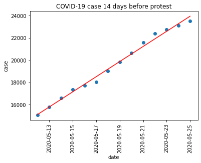

```python
# plot data and regression 14days before May 26th
x_axis = range(0, len(floyd_bf['positive'].tolist()))
y_axis = floyd_bf['positive'].tolist()

reg = np.polyfit(x = x_axis, y = y_axis, deg = 1)
ry = np.poly1d(reg)
yvals_bf = ry (x_axis)
print("regression before protest is :", ry)

plt.title("COVID-19 case 14 days before protest")
plt.xlabel("date")
plt.ylabel("case")
plt.xticks(rotation = 'vertical')
plt.scatter(floyd_bf['date'], y_axis)
plt.plot(floyd_bf['date'],yvals_bf,color='red')
```

```
regression after protest is :
384.1 x + 2.463e+04
```

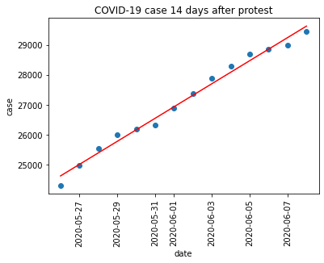

```python
# plot data and regression 14 days after May 26th
x_axis = range(0, len(floyd_af['positive'].tolist()))
y_axis = floyd_af['positive'].tolist()

reg = np.polyfit(x = x_axis, y = y_axis, deg = 1)
ry = np.poly1d(reg)
yvals_bf = ry (x_axis)
print("regression after protest is :", ry)

plt.title("COVID-19 case 14 days after protest")
plt.xlabel("date")
plt.ylabel("case")
plt.xticks(rotation = 'vertical')
plt.scatter(floyd_af['date'], y_axis)
plt.plot(floyd_af['date'],yvals_bf,color='red')
```

### **Protest might not increased the spread Covid-19**

By comparing the regression slope value of both before period and after period, it seems the slope value has decreased after the protest. The value decreased from 681.3 to 384.1. The value shows it has decreased almost half of the before period. The protest may prevent the spread of Covid-19 instead?

In the next section, we will take a deeper look at the data by comparing the testing positive rate and the daily testing number to help us to make a better conclusion.

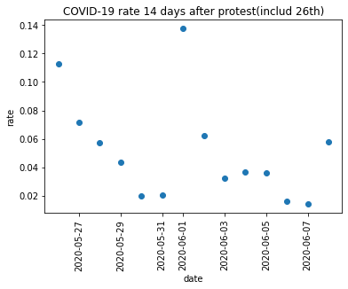

```python
# plot positive rate 14 days before May 26th
idx = 0
rate_lst = []
while idx < 14:
  rate = floyd_af['positiveIncrease'].iloc[idx] / floyd_af['totalTestResultsIncrease'].iloc[idx]
  rate_lst.append(rate)
  idx = idx+1

plt.title("COVID-19 rate 14 days after protest(includ 26th)")
plt.xlabel("date")
plt.ylabel("rate")
plt.xticks(rotation = 'vertical')
plt.scatter(floyd_af['date'], rate_lst)
```

[figure not shown]

```python
# plot positive rate 14 days after May 26th
idx = 0
rate_lst = []
while idx < 14:
  rate = floyd_bf['positiveIncrease'].iloc[idx] / floyd_bf['totalTestResultsIncrease'].iloc[idx]
  rate_lst.append(rate)
  idx = idx+1

plt.title("COVID-19 rate 14 days before protest(includ 26th)")
plt.xlabel("date")
plt.ylabel("rate")
plt.xticks(rotation = 'vertical')
plt.scatter(floyd_bf['date'], rate_lst)
```

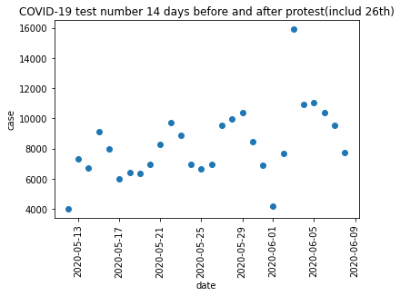

```python
# plot daily test number 14 days before and after May 26th
daily_test = pd.concat([floyd_bf, floyd_af])

idx = 0
daily_lst = []

while idx < 28:
  daily_lst.append(daily_test['totalTestResultsIncrease'].iloc[idx])
  idx = idx+1

plt.title("COVID-19 test number 14 days before and after protest(includ 26th)")
plt.xlabel("date")
plt.ylabel("case")
plt.xticks(rotation = 'vertical')
plt.scatter(daily_test['date'], daily_lst)
```

### **It is hard to tell whether protest spread the Covid-19 or not.**

The rate plot of both before and after periods has similar trends. Both of them have a shape like two backslashes. Both of them start from a large rate value then start decreasing for 4 to 5 days. Then it started again from a large rate value.Although the positive rate plots cannot help us to explain why the regression slope decreases, the daily test plot will give us more information.

In the daily test number plot for both periods, there is an outlier and there is no obvious trend globally on the graph. However, the data on May 29th to June 1st has a stable decrease trend. This means the testing number has a dramatic decrease after the protest started. This might due to the places that collected samples for testing were not able to perform the sampling. And that is a potential reason why June 3rd has the highest number that more than the rest of data because people were not able to do the test in the previous day and finally get the chance to do so. Since the daily testing number has a stable decrease after the protest and there is an outlier after the decrease, both might affect the data of the positive rate.

In order to acquire more evidence to answer the question, the data of the particular cities that hold protest should be analyzed. The future analysis should collect information of when and which city holds protest. Then the similar analyzation should be performed to compare the data before the protest and data after the protest for that particular city.

## **Conclusion**

In this project, we were able to determine that Thanksgiving helps the spread of Covid-19 by comparing the data 14 days before and after Thanksgiving. The person who traveled through public trafic like airplanes caught the virus then spread to the whole family members who stayed with him during the Thanksgiving might be the potential explanation of the increase.

In first part of the project we found that there is an exponential increase in both the number of people with the Covid-19 and the numbers of poeple covered.The growth rate for total positive population is almost twice than the growth rate for total recovered populaton, which means U.S.A are face medical shortage.

And in second part of the project we assume that the increase of positive case of COVID-19 may related to whether people are follow the instruction. However, the data analysis to determine if masks help people protect themself from the spread of virus were not able to answer. It requires better data to help us to answer the question. Those data should be people in that area strictly following the order to wear masks when the order is effective. Then it decreases the interference of people who do not follow the order.

Although the data analysis of determining which protest will spread the virus does not show a clear result, a better analysis can be performed by selecting well chosen data of cities that hold protest. In this project, the smallest geographical scale is states. Since the protests mainly happened in cities, data of the whole states might not have reflected the impact of a city.

### *By the way, stay safe :)*

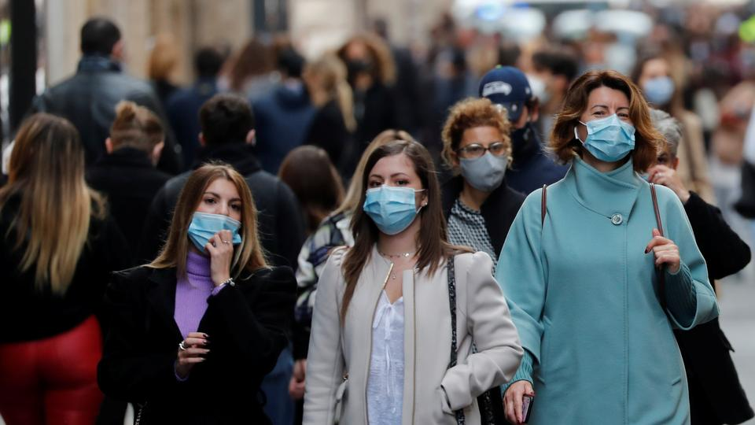